# Hall of Fame WAR

Brice Keown

2020-09-28

## Getting started with WAR

I wanted to recreate the cumulative WAR graphs popular on [FanGraphs](https://fangraphs.com) and elsewhere. Specifically I wanted to graph the WAR totals of the top hall of fame pitchers.

First, we read the necessary tables in from Lahman and download pitcher WAR from our friends at baseball reference.

```r
data(Teams)
data("People")
data("HallOfFame")
WAR_data <- read_csv(file = "https://www.baseball-reference.com/data/war_daily_pitch.txt")
```

### Career WAR

Next, we do some joins to get one table with pitchers who were in the HoF. and take a quick look at career WARs

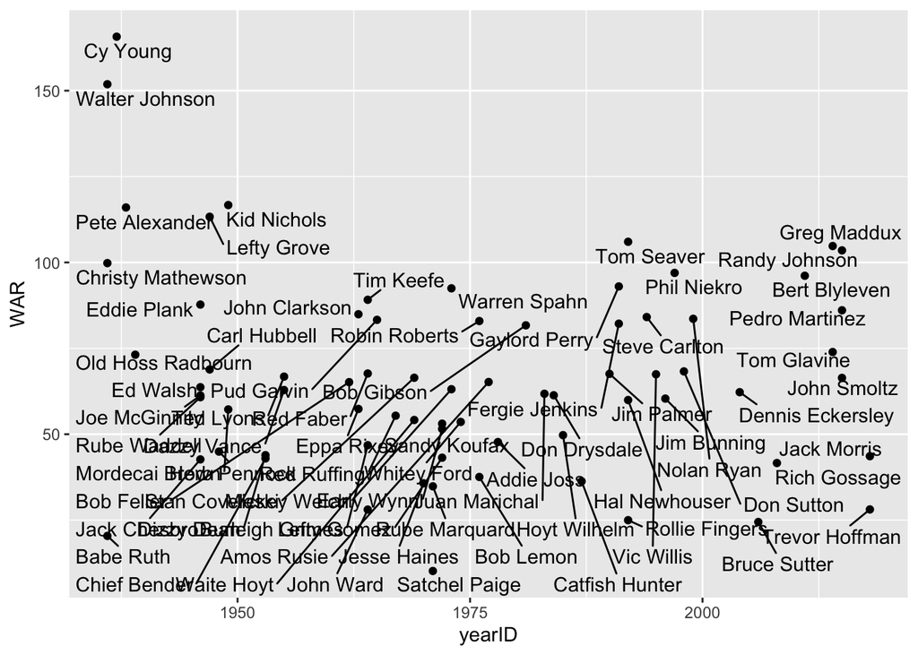

```r
HOF <- HallOfFame %>%
  filter(inducted == "Y", category =="Player")

#add common names to the list of players
HOF_with_names <- HOF %>% inner_join(People, by = "playerID") %>% unite("name_common","nameFirst":"nameLast",sep=" ", remove=TRUE)

#The Lahman data has handy unique identifiers used by b-r and other data sources.  Here we rename our b-r data to match the Lahman name.  Prob a way to handle this in the join but trying to keep steps clear.
colnames(WAR_data)[colnames(WAR_data) == 'player_ID'] <- 'bbrefID'

#join HoF with the name data by uuid, make sure R knows WAR is numeric
HOF_with_names_and_war <- HOF_with_names %>% inner_join(WAR_data, by="bbrefID")
HOF_with_names_and_war$WAR <- as.numeric(HOF_with_names_and_war$WAR)

#First we just calculate total WAR for each player. n.b. it probably makes more sense to do all this math on all players and then select the hof players at the very end but whatever.
HOF_with_names_and_war_summed <- HOF_with_names_and_war %>%
  group_by(name_common.x, yearID) %>%
  summarise(WAR = sum(WAR)) %>% filter(WAR>10 )

#simple plot of hof pitchers with > 10 career WAR.
p <- ggplot(HOF_with_names_and_war_summed, mapping=aes(x=yearID,y=WAR,label=name_common.x))
p + geom_point() + geom_text_repel(aes(label=name_common.x),hjust=0, vjust=0)
```

Obviously this is a mess, but was useful to make sure the totals look ok.